# Hypothesis Testing in (Dis)Similarity of Ecological Communities

Oleksii Dubovyk

5/18/2021

*oadubovyk@gmail.com*

## The Basics of Similarity Indices

There are many different ways to describe an ecological community: by a mere number of species or using some “diversity” index (Simpson, Shannon; Hurblert’s PIE; Hill’s numbers) that not always has something to do with ecology (see Hurlbert 1971[^1], Gotelli & Ellison 2018[^2]). Yet, the most informative way to describe a community is the raw community structure data, i.e., the metrics of abundance (density, number of individuals etc.) referred to particular taxa.

It is possible to compare the taxonomic composition or structure of ecological communities using a variety of indices (Wolda 1981)[^3]. This way is more preferable because comparing a mere community parameter (some diversity index) is meaningless: two communities composed of totally different taxa can have identical diversity metric.

There are two ways to compare the communities that differ in the way the data is being held. The first group of indices treat the community structure as presence-absence data. The most popular indices are Jaccard and Sorensen:

$S_{Jaccard} = \frac{s_{A \cup B}}{s_A + s_B - s_{A \cup B}}$,

where

$S_{Sorensen} = \frac{2 \cdot s_{A \cup B}}{s_A + s_B}$

where the notation is the same.

The second way treats the community structure data directly. For example, one could imagine a community as a point in multidimensional space of taxa abundances, thus, the squared Euclidian distance can be measured between the communities (points):

$1 - D^2 = 1 - \sum_{i=1}^{R} n_{A,i}^2 - n_{B,i}^2$

where $n_{j, i}$ - abundance metric value of taxa $i$ in community $j$, $R$ is species richness.

Another popular metric is Bray-Curtis index:

$1 - BC = 1 - \frac{\sum_{i=1}^{R} |n_{A, i} - n_{B, i}|}{\sum_{i=1}^{R} n_{A, i} + n_{B, i}}$

where the notation is the same.

It is easy to write the functions for every possible similarity index in R. I have done this several years ago and united them within a package [`ancends`](https://github.com/OleksiiDubovyk/ancends/blob/master/ancends_0.1.1.tar.gz?raw=true) (honestly, I do not remember exactly what did I want to say with this name). To use the code here you would need to download this package as an archive and to install it (RStudio > Tools > Install Packages > Install from: Package Archive File (.tar.gz)).

```r
library(ancends)
```

As an example dataset, you will need to use vectors of taxa abundances. I suggest using my raw data[^4] on abundances of 67 bird species at 59 500-m transects among 16 forested areas in and around Lviv, Ukraine:

```r
lbt <- read.csv("https://github.com/OleksiiDubovyk/test/files/6498008/lbt.csv")
rownames(lbt) <- lbt$Transect
lbt <- lbt[,-1]
head(lbt)
```

```
##        BP1 BP2 BP3 BP4 OP1 OP2 HC1 HC2 HC3 LC1 LC2 YC1 YC2 PP1 PP2 PP3 LP1 SP1
## ANAPLA   0   0   0   0   0   0   0   0   0   0   0   0   0   1   0   0   0   0
## ACCNIS   0   0   0   0   0   0   0   0   0   0   0   0   0   0   0   0   0   0
## BUTBUT   0   0   0   0   0   0   0   0   0   0   0   0   0   0   0   1   0   0
## COLLIV   0   0   0   0   0   0   0   0   0   0   0   0   0   0   0   0   5  10
## COLPAL   1   1   1   1   3   2   2   3   3   2   6   3   2   6   6   6   4   6
## COLOEN   0   0   0   0   0   0   0   0   0   0   0   0   0   0   1   1   0   0
##        SP2 SP3 ZP1 ZP2 ZP3 FP1 AP1 AP2 VP1 VP2 VP3 VP4 VP5 KF1 KF2 KF3 KF4 KF5
## ANAPLA   0   1   0   0   0   0   1   0   0   0   0   0   0   0   0   0   0   0
## ACCNIS   0   0   0   0   0   0   0   0   0   0   0   0   0   1   0   0   0   0
## BUTBUT   0   0   0   0   0   0   0   0   0   0   0   0   0   0   1   0   0   0
## COLLIV   3  22   2   2   2   2   2   2   2   2   2   2   2   2   2   2   2   2
## COLPAL   5   8   4   4   5   9   6   6   4   3   4   3   2   2   1   2   3   1
## COLOEN   0   1   1   0   0   1   0   0   0   1   0   0   0   0   1   2   0   1
##        KF6 KF7 KF8 KF9 KF10 BF1 BF2 BF3 BF4 BF5 BF6 RF1 RF2 RF3 RF4 RF5 RF6 VF1
## ANAPLA   0   0   0   0    0   0   0   0   0   0   0   0   0   0   0   0   0   0
## ACCNIS   0   0   0   0    0   1   0   0   0   0   0   0   0   0   0   0   0   0
## BUTBUT   0   0   0   0    1   0   0   0   1   0   1   0   0   0   1   0   0   0
## COLLIV   2   2   2   2    2   2   2   2   2   2   2   2   2   2   2   2   2   2
## COLPAL   0   2   0   0    0   1   2   3   0   1   1   1   1   1   0   0   0   2
## COLOEN   0   1   0   0    0   0   0   3   2   0   1   0   0   0   0   0   0   0
##        VF2 VF3 VF4 VF5 VF6
## ANAPLA   0   0   0   0   0
## ACCNIS   0   0   1   0   0
## BUTBUT   0   0   0   0   0
## COLLIV   2   2   2   2   2
## COLPAL   3   1   1   1   2
## COLOEN   1   1   2   1   0
```

```r
S_j <- jaccard(data.frame(lbt$BP1, lbt$BP2))
S_bc <- braycurtis(data.frame(lbt$BP1, lbt$BP2))
similarities <- c(S_j, S_bc)
names(similarities) <- c("Jaccard", "Bray-Curtis")
similarities
```

```
##     Jaccard Bray-Curtis
##   0.6296296   0.7956989
```

It means that we have 62.9% of taxonomic overlap between two communities and their structures, according to Bray-Curtis index, are 79.6% similar.

Of course, we can calculate these values manually to validate the results. Firstly, take a look at these two vectors:

```r
lbt[,1:2]
```

```
##        BP1 BP2
## ANAPLA   0   0
## ACCNIS   0   0
## BUTBUT   0   0
## COLLIV   0   0
## COLPAL   1   1
## COLOEN   0   0
## STRDEC   0   0
## CUCCAN   0   0
## STRALU   0   0
## STRURA   0   0
## JYNTOR   0   0
## DRYMAR   0   0
## PICCAN   0   0
## PICVIR   0   0
## DENMAJ   1   1
## DENSYR   0   1
## DENMED   0   0
## DENLEU   0   0
## DENMIN   0   0
## DELURB   0   0
## HIRRUS   0   0
## MOTALB   0   0
## LANCOL   0   0
## ORIORI   1   1
## STUVUL   1   0
## GARGLA   1   1
## PICPIC   1   0
## CORCOR   0   0
## CORCOX   0   0
## TROTRO   1   1
## HIPICT   0   0
## SYLATR   6   3
## SYLBOR   0   0
## SYLCUR   0   0
## SYLCOM   0   0
## PHYTRO   0   0
## PHYSIB   1   2
## PHYCOL   4   5
## FICALB   0   2
```

[output cut: 13 more lines]

```
## POEPAL   1   1
## LOPCRI   0   0
## PERATE   0   0
## PARMAJ   4   4
## SITEUR   2   2
## CERFAM   0   1
## CERBRA   0   1
## FRICOE   6   6
## CARCAR   0   0
## SERSER   0   0
## SPISPI   0   0
## CHLCHL   0   0
## LOXCUR   0   0
## COCCOC   1   1
## EMBCIT   0   0
```

Next, we should calculate the number of shared species $s_{A \cup B}$ and total numbers of species in both communities ($s_A$ and $s_B$):

```r
s_A <- sum(lbt$BP1 > 0)
s_B <- sum(lbt$BP2 > 0)
s_AB <- sum(sapply(1:nrow(lbt), function(i){
  lbt$BP1[i] > 0 & lbt$BP2[i] > 0
}))
s <- c(s_AB, s_A, s_B)
names(s) <- c("s_AB", "s_A", "s_B")
s
```

```
## s_AB  s_A  s_B
##   17   21   23
```

We see that $S_{Jaccard} = \frac{s_{A \cup B}}{s_A + s_B - s_{A \cup B}} = \frac{17}{21+23-17}$ indeed equals $0.6296296$.

Recreating Bray-Curtis index calulation is a little bit more complicated:

```r
cbind(lbt$BP1, lbt$BP2, abs(lbt$BP1 - lbt$BP2), lbt$BP1 + lbt$BP2)
```

```
##       [,1] [,2] [,3] [,4]
##  [1,]    0    0    0    0
##  [2,]    0    0    0    0
##  [3,]    0    0    0    0
##  [4,]    0    0    0    0
##  [5,]    1    1    0    2
##  [6,]    0    0    0    0
##  [7,]    0    0    0    0
##  [8,]    0    0    0    0
##  [9,]    0    0    0    0
## [10,]    0    0    0    0
## [11,]    0    0    0    0
## [12,]    0    0    0    0
## [13,]    0    0    0    0
## [14,]    0    0    0    0
```

[output cut: 53 more lines]

```r
#first sum
sum(abs(lbt$BP1 - lbt$BP2))
```

```
## [1] 19
```

```r
#second sum
sum(lbt$BP1 + lbt$BP2)
```

```
## [1] 93
```

Again, $1 - BC = 1 - \frac{\sum_{i=1}^{R} |n_{A, i} - n_{B, i}|}{\sum_{i=1}^{R} n_{A, i} + n_{B, i}} = 1 - \frac{19}{93} = 1 - 0.2043011 =0.7956989$ which is exactly what we needed to show. Thus we believe that we can trust the function defined in `ancends`, at least `jaccard` and `braycurtis`.

## Hypothesis Testing

But what is the meaning of those indices? When can we say that two communities are different? Below 50%? But this cut-off level would not make sense due to the fact that different indices yield different values with identical data.

We can approach this question from the perspective of classical frequentist-based hypothesis testing: p-value corresponding to the probability of rejecting the null hypothesis when it is true would be useful here. But firstly we should define the statistical hypotheses.

Let $a$ and $b$ be two sets of labeled objects (individuals that belong to some taxa $i$). These two sets are sampled from the big sets $A$ and $B$. Since we are interested whether $a$ and $b$ are significantly different, we may define the hypotheses that

- The Null hypothesis $H_0$:
  - the samples were sampled from the same sets, i.e., $a \subset A = B \supset b$
- The Alternative hypothesis $H_A$:
  - the samples were sampled from the different sets, i.e., $a \subset A \neq B \supset b$.

Thus, we would need to yield a distribution of a similarity index under the null hypothesis (two samples were taken from a shared “metacommunity” pool).

For example, for two samples

```r
df <- lbt[,1:2]
```

the pool of labeled individuals would be

```r
pool <- unlist(sapply(1:nrow(df), function(i){
  sapply(1:2, function(j){
    rep(rownames(df[i,]), df[i, j])
  })
}))
sort(pool)
```

```
##  [1] "AEGCAU" "CERBRA" "CERFAM" "COCCOC" "COCCOC" "COLPAL" "COLPAL" "CYACAE"
##  [9] "CYACAE" "CYACAE" "CYACAE" "DENMAJ" "DENMAJ" "DENSYR" "ERIRUB" "ERIRUB"
## [17] "ERIRUB" "ERIRUB" "ERIRUB" "FICALB" "FICALB" "FRICOE" "FRICOE" "FRICOE"
## [25] "FRICOE" "FRICOE" "FRICOE" "FRICOE" "FRICOE" "FRICOE" "FRICOE" "FRICOE"
## [33] "FRICOE" "GARGLA" "GARGLA" "MUSSTR" "ORIORI" "ORIORI" "PARMAJ" "PARMAJ"
## [41] "PARMAJ" "PARMAJ" "PARMAJ" "PARMAJ" "PARMAJ" "PARMAJ" "PHOOCH" "PHYCOL"
## [49] "PHYCOL" "PHYCOL" "PHYCOL" "PHYCOL" "PHYCOL" "PHYCOL" "PHYCOL" "PHYCOL"
## [57] "PHYSIB" "PHYSIB" "PHYSIB" "PICPIC" "POEMON" "POEPAL" "POEPAL" "SITEUR"
## [65] "SITEUR" "SITEUR" "SITEUR" "STUVUL" "SYLATR" "SYLATR" "SYLATR" "SYLATR"
## [73] "SYLATR" "SYLATR" "SYLATR" "SYLATR" "SYLATR" "TROTRO" "TROTRO" "TURMER"
## [81] "TURMER" "TURMER" "TURMER" "TURMER" "TURMER" "TURMER" "TURMER" "TURMER"
## [89] "TURMER" "TURPHI" "TURPHI" "TURPHI" "TURPHI"
```

so that there is one individual of the Long-Tailed Tit *Aegithalos caudatus*, Short-Toed Treecreeper *Certhia brachydactyla*, Eurasian Treecreeper *Certhia familiaris* two Hawfinches *Coccothraustes coccothraustes* and so on.

Under the null hypothesis, the samples were collected from this pool so that the first community would be sampled to collect the number of individuals that have been collected in the original vector:

```r
n1 <- sum(df[1])
n1
```

```
## [1] 47
```

```r
p1 <- sample(x = pool, size = n1)
p1
```

```
##  [1] "DENMAJ" "PHYSIB" "ORIORI" "PARMAJ" "FRICOE" "FICALB" "FRICOE" "FRICOE"
##  [9] "FRICOE" "PHYCOL" "GARGLA" "PARMAJ" "TROTRO" "SYLATR" "COCCOC" "PHYCOL"
## [17] "CYACAE" "CYACAE" "DENMAJ" "PHYSIB" "TURMER" "SITEUR" "TURMER" "FRICOE"
## [25] "TURMER" "SYLATR" "ORIORI" "PHYCOL" "PHYCOL" "SYLATR" "PHYCOL" "PHYSIB"
## [33] "TROTRO" "FRICOE" "TURMER" "ERIRUB" "TURPHI" "TURMER" "PHYCOL" "GARGLA"
## [41] "SYLATR" "PARMAJ" "FRICOE" "PARMAJ" "TURMER" "FRICOE" "FICALB"
```

```r
ps1 <- sapply(rownames(df), function(i){
  sum(sapply(p1, function(j){
    j == i
  }))
})
ps1
```

```
## ANAPLA ACCNIS BUTBUT COLLIV COLPAL COLOEN STRDEC CUCCAN STRALU STRURA JYNTOR
##      0      0      0      0      0      0      0      0      0      0      0
## DRYMAR PICCAN PICVIR DENMAJ DENSYR DENMED DENLEU DENMIN DELURB HIRRUS MOTALB
##      0      0      0      2      0      0      0      0      0      0      0
## LANCOL ORIORI STUVUL GARGLA PICPIC CORCOR CORCOX TROTRO HIPICT SYLATR SYLBOR
##      0      2      0      2      0      0      0      2      0      4      0
## SYLCUR SYLCOM PHYTRO PHYSIB PHYCOL FICALB FICPAR MUSSTR REGIGN PHOPHO PHOOCH
##      0      0      0      3      6      2      0      0      0      0      0
## ERIRUB LUSLUS TURPIL TURMER TURPHI AEGCAU CYACAE POEMON POEPAL LOPCRI PERATE
##      1      0      0      6      1      0      2      0      0      0      0
## PARMAJ SITEUR CERFAM CERBRA FRICOE CARCAR SERSER SPISPI CHLCHL LOXCUR COCCOC
##      4      1      0      0      8      0      0      0      0      0      1
## EMBCIT
##      0
```

so that we have a sample expected to be collected under the null hypothesis for the first vector. This can be repeated for the second vector:

```r
n2 <- sum(df[2])
p2 <- sample(x = pool, size = n2)
ps2 <- sapply(rownames(df), function(i){
  sum(sapply(p2, function(j){
    j == i
  }))
})
```

and we have two samples to be compared with some similarity index:

```r
pseudo_df <- data.frame(ps1, ps2)
jaccard(pseudo_df)
```

```
## [1] 0.6086957
```

After repeating this operation many times, a distribution of the index can be inferred.

```r
resample.communities <- function(com1, com2){
  df <- data.frame(com1 = com1, com2 = com2)
  pool <- unlist(sapply(1:nrow(df), function(i){
    sapply(1:2, function(j){
      rep(rownames(df[i,]), df[i, j])
    })
  }))
  n1 <- sum(df[1])
  n2 <- sum(df[2])
  perm1 <- sample(x = pool, size = n1)
  perm2 <- sample(x = pool, size = n2)
  pseudo1 <- sapply(rownames(df), function(i){
    sum(sapply(perm1, function(j){
      j == i
    }))
  })
  pseudo2 <- sapply(rownames(df), function(i){
    sum(sapply(perm2, function(j){
      j == i
    }))
  })
  jaccard(data.frame(pseudo1, pseudo2))
}
```

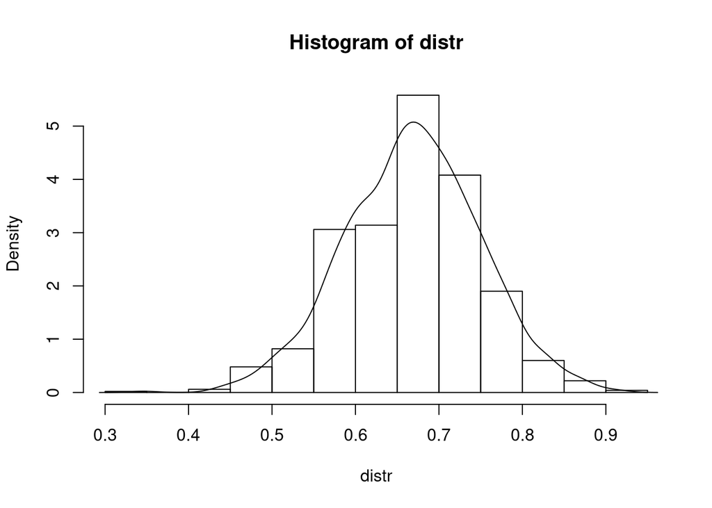

```r
distr <- numeric(1000)
for (i in 1:1000){
  distr[i] <- resample.communities(lbt[,1], lbt[,2])
}
hist(distr, freq = F)
lines(density(distr))
```

It is known that the observed Jaccard index equals 0.6296296. Since under the null hypothesis the two communities are similar, i.e., a similarity metric should $S \to 1$, the extreme values of the metric are lower-tailed. Thus, the p-value in this case is probability of observation of the observed metric value or lower.

```r
sum(distr <= 0.6296296)/1000
```

```
## [1] 0.309
```

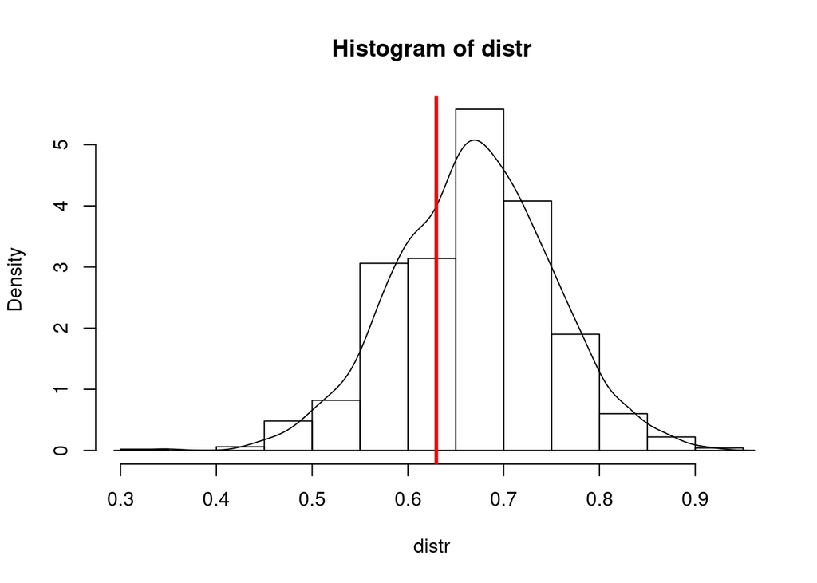

```r
hist(distr, freq = F)
lines(density(distr))
abline(v = 0.6296296, col = "red", lwd = 3)
```

In that case, there is not enough evidence to decide that these two communities were sampled from different metacommunities. It makes sense, because the data were collected from the transects few hundred meters apart in the same forest.

```r
compare.communities <- function(com1, com2, nperm = 1000, distance = ancends::jaccard, show.hist = F){
  fnct <- distance
  resample.communities <- function(com1 = com1, com2 = com2){
    df <- data.frame(com1 = com1, com2 = com2)
    pool <- unlist(sapply(1:nrow(df), function(i){
      sapply(1:2, function(j){
        rep(rownames(df[i,]), df[i, j])
      })
    }))
    n1 <- sum(df[1])
    n2 <- sum(df[2])
    perm1 <- sample(x = pool, size = n1)
    perm2 <- sample(x = pool, size = n2)
    pseudo1 <- sapply(rownames(df), function(i){
      sum(sapply(perm1, function(j){
        j == i
      }))
    })
    pseudo2 <- sapply(rownames(df), function(i){
      sum(sapply(perm2, function(j){
        j == i
      }))
    })
    df <- data.frame(pseudo1, pseudo2)
    fnct(df)
  }
  distr <- numeric(nperm)
  for (i in 1:nperm){
    distr[i] <- resample.communities(lbt[,1], lbt[,2])
  }
  metric <- fnct(data.frame(com1 = com1, com2 = com2))
  rslt <- c(round(metric, 3), ifelse(sum(distr <= metric)/nperm == 0,
                                     paste("<", 1/nperm),
                                     sum(distr <= metric)/nperm))
  names(rslt) <- c("Metric", "p-value")
  if (show.hist){
    hist(distr, main = paste("Metric = ", rslt[1], "; p-value = ", rslt[2], sep = ""),
         freq = F, xlab = "Metric", xlim = c(0, 1))
    lines(density(distr), col = "blue")
    abline(v = rslt[1], col = "red", lwd = 3)
  }else{
    rslt
  }
}
```

The example of use:

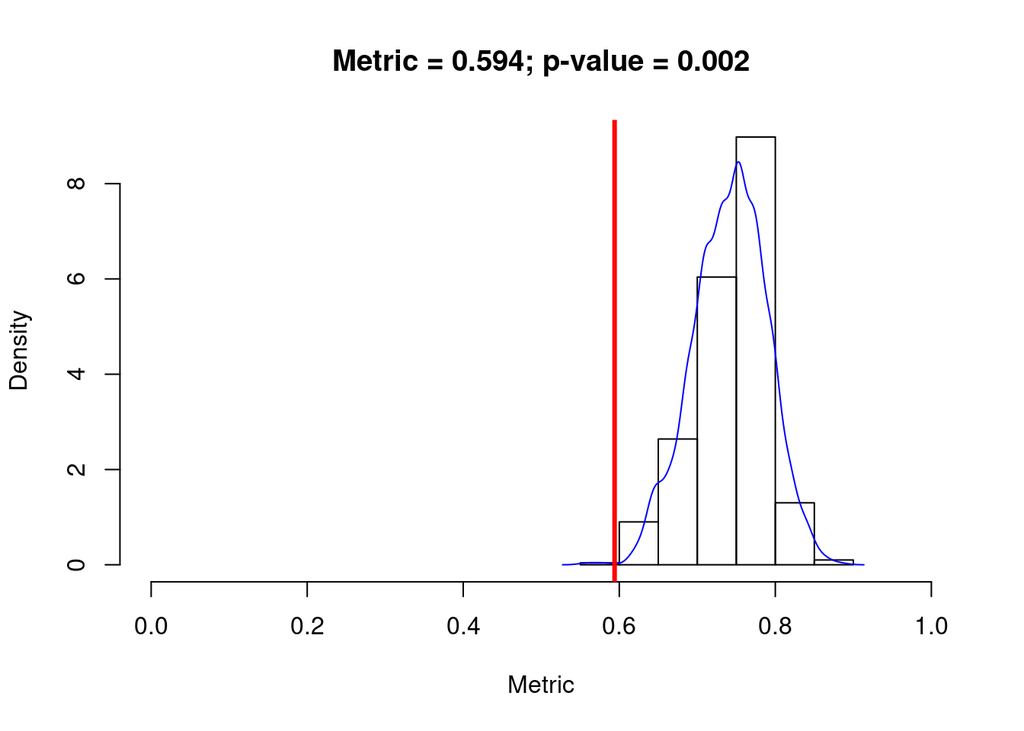

```r
compare.communities(lbt[1], lbt[5], nperm = 1000, distance = ancends::braycurtis, show.hist = T)
```

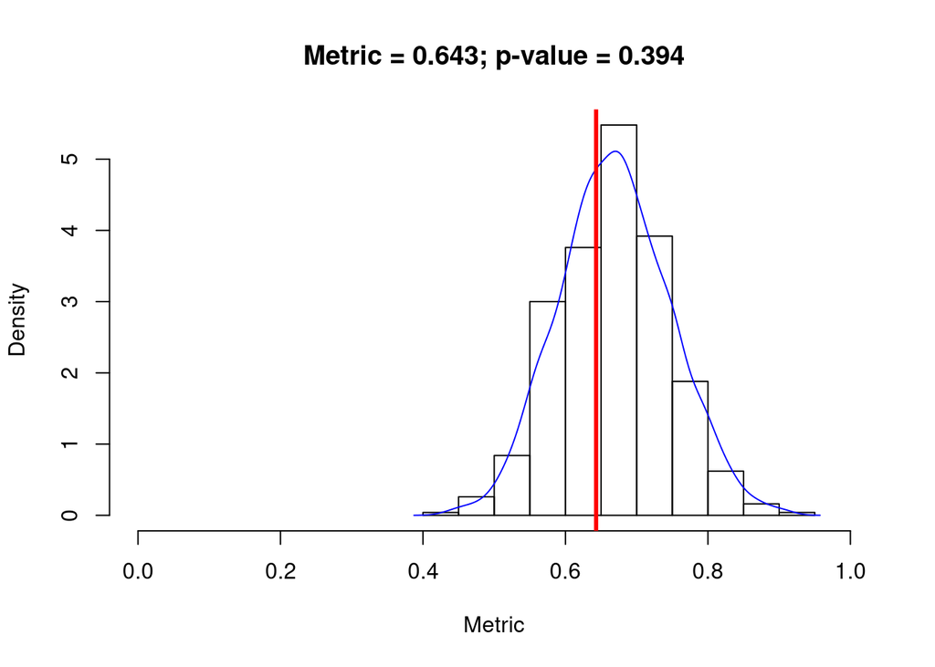

```r
compare.communities(lbt[1], lbt[10], nperm = 1000, distance = ancends::jaccard, show.hist = T)
```

```r
compare.communities(lbt[1], lbt[15], nperm = 1000, distance = ancends::jaccard, show.hist = F)
```

```
##  Metric p-value
##   0.536   0.037
```

```r
compare.communities(lbt[1], lbt[20], nperm = 1000, distance = ancends::braycurtis, show.hist = F)
```

```
##    Metric   p-value
##   "0.534" "< 0.001"
```

[^1]: Hurlbert, S.H. (1971) The nonconcept of species diversity: A critique and alternative parameters. *Ecology 52*(4), 577-586. https://doi.org/10.2307/1934145
[^2]: Gotelli, N.J., & Ellison, A.M. (2018). *A Primer of Ecological Statistics* (2nd ed.). New York: Oxford University Press.
[^3]: Wolda, H. (1981) Similarity indices, sample size and diversity. *Oecologia 50*, 296-302. https://doi.org/10.1007/BF00344966)
[^4]: Dubovyk, O., Kuzyo, H., & Bokotey, A. (2020). Density variation in “rare” breeding birds in native forests and urban parks. *Geo&Bio 19*, 20-31. http://doi.org/10.15407/gb1904